# Practical Machine Learning Project

Dorota

21 June 2015

## Goal

Build a machine learning algorithm to predict activity quality from activity monitors using data from accelerometers on the belt, forearm, arm, and dumbell of 6 participants. The training data for this project are available here: https://d396qusza40orc.cloudfront.net/predmachlearn/pml-training.csv

## Loading and pre-processing the data

After loading csv file I decided to remove following columns : X, 3 timestamps columns and 2 windows columns as they do not contain any relevant info for predictions.

Data was also split into 60% training and 40% testing set.

As a part of pre processing the data, missing values were imputated with median, near zero variance features were removed, and user_name variable was dummy coded.

```r
library(caret)
library(parallel)
library(doParallel)

#load raw data and remove unecessary columns
data <- read.csv("pml-training.csv", header = TRUE)
data$classe <- factor(data$classe)
data<-data[,-c(1,3,4,5,6,7)]

#split data
set.seed(9876)
trainIndex <- createDataPartition(y = data$classe, p=0.6,list=FALSE)
training <- data[trainIndex,]
testing<- data[-trainIndex,]

#pre processing
NAColumn<- apply(training,2,function(x) {sum(is.na(x))})
preProcValues<-preProcess(training[,NAColumn>0], method="medianImpute")
trainProc1 <- predict(preProcValues, training)

nzv <- nearZeroVar(trainProc1)
trainProc2<- trainProc1[, -nzv]

dummy<-dummyVars(~user_name, data=trainProc2)
trainProc<-cbind(predict(dummy,trainProc2),trainProc2[-1])
```

## Building models

For classifiaction problems there are several machine lerning models that can be used. For the purpose of this exercise we comapte 3 of them : Linear Discriminant Analysis, Classification Tree and Random Forest. To estimate how how accurately those models will perform in test data 2 folded 5 repeated 2-fold Cross Validation ws used.

```r
#random seed
registerDoParallel(makeCluster(detectCores()))
set.seed(9876)
## 5 repeaed 2 fold CV
ctrl<- trainControl(method = "repeatedcv", number = 2, repeats = 5)
model1<-train(classe ~ ., method = 'lda', data =trainProc, trControl=ctrl)
model2<-train(classe ~ ., method = 'rpart', data =trainProc, trControl=ctrl)
model3<-train(classe ~ ., method = 'rf', data =trainProc, trControl=ctrl)
```

Estimate of the true prediction error are as follow:

- Linear Discriminant Analysis 27 %
- Classification Tree 48 %
- Random Forest 2 %

As espected Random Forest does perfom the best, with estimated error only 2 % (accuaracy 98 %), so it’s will be selected as final model.

## Predicting outcome for test data

By applying the Random Forect model to test data we can see the actual prediction error/accuracy.

```r
#Applying the same transformation as to the train data
testProc0 <- predict(preProcValues, testing)
testProc <- cbind(predict(dummy,testProc0),testProc0[-1])

# Prediction
prediction<- predict(model3, testProc)
confusionMatrix(prediction, testProc$classe)[2:3]
```

```
## $table
##           Reference
## Prediction    A    B    C    D    E
##          A 2230   16    0    0    0
##          B    0 1497    9    2    0
##          C    0    4 1351   19    4
##          D    0    1    8 1264    2
##          E    2    0    0    1 1436
##
## $overall
##       Accuracy          Kappa  AccuracyLower  AccuracyUpper   AccuracyNull
##      0.9913332      0.9890351      0.9890255      0.9932638      0.2844762
## AccuracyPValue  McnemarPValue
##      0.0000000            NaN
```

## Variables importance

The 10 most important predictors in the model are listed below.

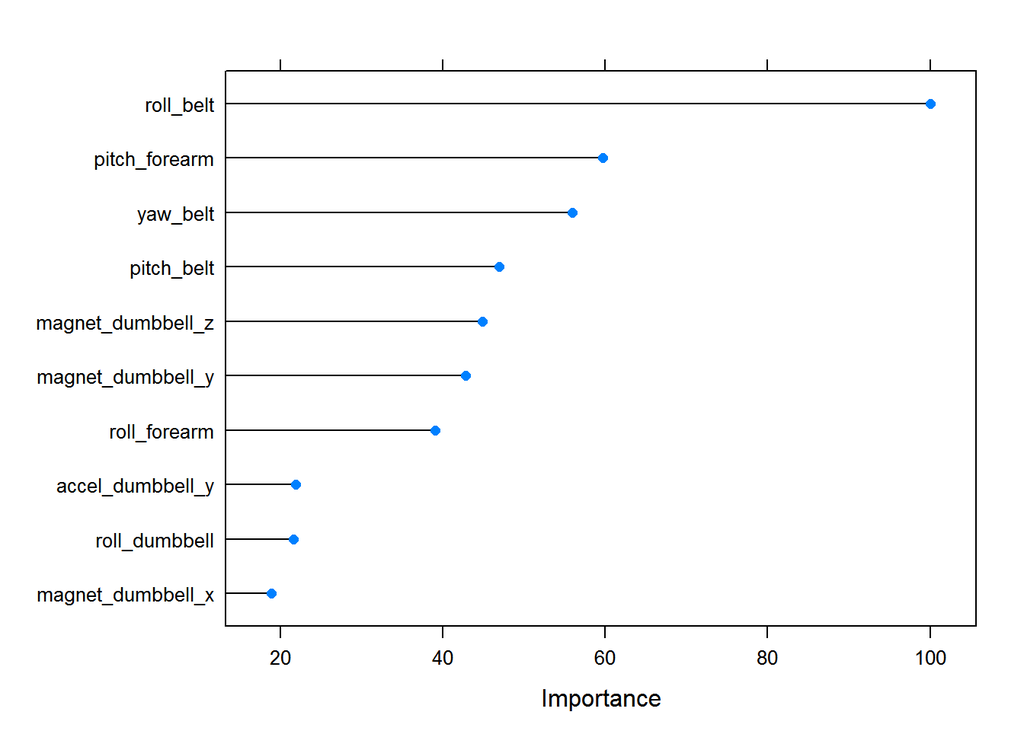